# House Price Prediction & Quality Classification

## Project Overview

This project analyzes residential housing data to understand the factors that influence property values and to build predictive models for house prices and overall property quality.

The workflow includes data preparation, exploratory data analysis, feature engineering, regression modeling, Random Forest modeling, XGBoost classification, class-imbalance handling, model evaluation, and feature importance analysis.

Two predictive problems are addressed:

1. Predicting house sale prices using regression models.
2. Classifying houses by overall quality using machine learning.

## Load Data

The repository contains separate training and test datasets.

```r
train_raw <- read.csv("house_prices_train.csv")
test_raw <- read_excel("house_prices_test.xlsx")

test_raw <- as.data.frame(test_raw)

# Convert numeric Excel columns consistently
test_raw[, sapply(test_raw, is.numeric)] <-
  lapply(test_raw[, sapply(test_raw, is.numeric)], as.numeric)

cat("Training data dimensions:", dim(train_raw), "\n")
```

```
## Training data dimensions: 900 13
```

```r
cat("Test data dimensions:", dim(test_raw), "\n")
```

```
## Test data dimensions: 90 13
```

## Data Quality Checks

```r
cat("Missing values in training data:",
    sum(is.na(train_raw)), "\n")
```

```
## Missing values in training data: 0
```

```r
cat("Missing values in test data:",
    sum(is.na(test_raw)), "\n")
```

```
## Missing values in test data: 0
```

```r
cat("Duplicate rows in training data:",
    sum(duplicated(train_raw)), "\n")
```

```
## Duplicate rows in training data: 0
```

```r
cat("Duplicate rows in test data:",
    sum(duplicated(test_raw)), "\n")
```

```
## Duplicate rows in test data: 0
```

## Data Preparation

The same preprocessing steps are applied to both the training and test datasets.

```r
prepare_data <- function(df) {

  # Remove YearBuilt because YearRemodAdd captures related information
  if ("YearBuilt" %in% names(df)) {
    df$YearBuilt <- NULL
  }

  # Remodel year categories
  df$YearRemodAdd <- cut(
    df$YearRemodAdd,
    breaks = c(1949, 2000, 2011),
    labels = c(
      "on or before 2000",
      "after 2000"
    ),
    include.lowest = TRUE
  )

  # Total rooms categories
  df$TotRmsAbvGrd <- cut(
    df$TotRmsAbvGrd,
    breaks = c(0, 5, 10, 15),
    labels = c(
      "0-5",
      "5-10",
      "10-15"
    ),
    include.lowest = TRUE
  )

  # Bedroom categories
  df$BedroomAbvGr <- cut(
    df$BedroomAbvGr,
    breaks = c(-1, 5, 15),
    labels = c(
      "less than or equal to 5",
      "More than 5"
    ),
    include.lowest = TRUE
  )

  df
}

train_reg <- prepare_data(train_raw)
test_reg <- prepare_data(test_raw)
```

### Factor Variables

```r
factor_cols <- c(
  "YrSold",
  "FullBath",
  "HalfBath",
  "BedroomAbvGr",
  "TotRmsAbvGrd",
  "Fireplaces",
  "YearRemodAdd",
  "OverallQual"
)

for (col in factor_cols) {

  train_levels <- unique(as.character(train_reg[[col]]))

  unknown_test_levels <- setdiff(
    unique(as.character(test_reg[[col]])),
    train_levels
  )

  if (length(unknown_test_levels) > 0) {
    stop(
      paste(
        "Unexpected test level in",
        col,
        ":",
        paste(unknown_test_levels, collapse = ", ")
      )
    )
  }

  train_reg[[col]] <- factor(
    train_reg[[col]],
    levels = train_levels
  )

  test_reg[[col]] <- factor(
    test_reg[[col]],
    levels = train_levels
  )
}

summary(train_reg)
```

```
##     LotArea        OverallQual             YearRemodAdd   BsmtFinSF1
##  Min.   :  1491   5      :244   after 2000       :303   Min.   :   0.0
##  1st Qu.:  7585   6      :235   on or before 2000:597   1st Qu.:   0.0
##  Median :  9442   7      :196                           Median : 384.0
##  Mean   : 10795   8      :104                           Mean   : 446.5
##  3rd Qu.: 11618   4      : 67                           3rd Qu.: 728.8
##  Max.   :215245   9      : 31                           Max.   :2260.0
##                   (Other): 23
##  FullBath HalfBath                  BedroomAbvGr TotRmsAbvGrd Fireplaces
##  2:467    1:337    less than or equal to 5:893   5-10 :635    0:421
##  1:405    0:558    More than 5            :  7   0-5  :249    1:397
##  3: 23    2:  5                                  10-15: 16    2: 78
##  0:  5                                                        3:  4
##
##
##
##    GarageArea      YrSold      SalePrice
##  Min.   :   0.0   2008:194   Min.   : 34900
##  1st Qu.: 336.0   2007:205   1st Qu.:130000
##  Median : 480.0   2006:183   Median :163000
##  Mean   : 472.6   2009:206   Mean   :183108
##  3rd Qu.: 576.0   2010:112   3rd Qu.:216878
##  Max.   :1390.0              Max.   :755000
##
```

## Exploratory Data Analysis

### Distribution of House Prices

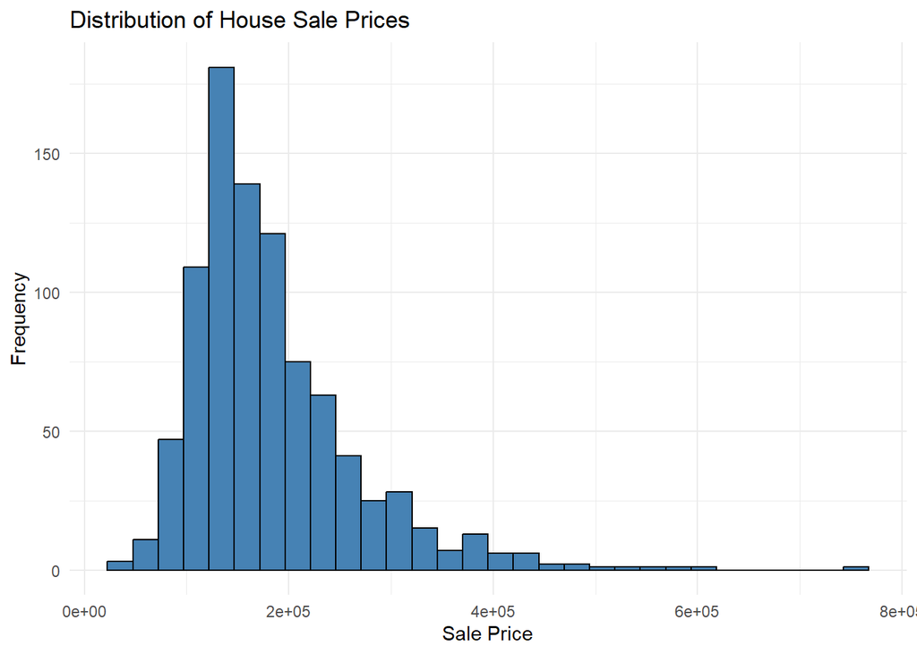

```r
ggplot(train_reg, aes(x = SalePrice)) +
  geom_histogram(
    bins = 30,
    fill = "steelblue",
    color = "black"
  ) +
  labs(
    title = "Distribution of House Sale Prices",
    x = "Sale Price",
    y = "Frequency"
  ) +
  theme_minimal()
```

### Garage Area and Sale Price

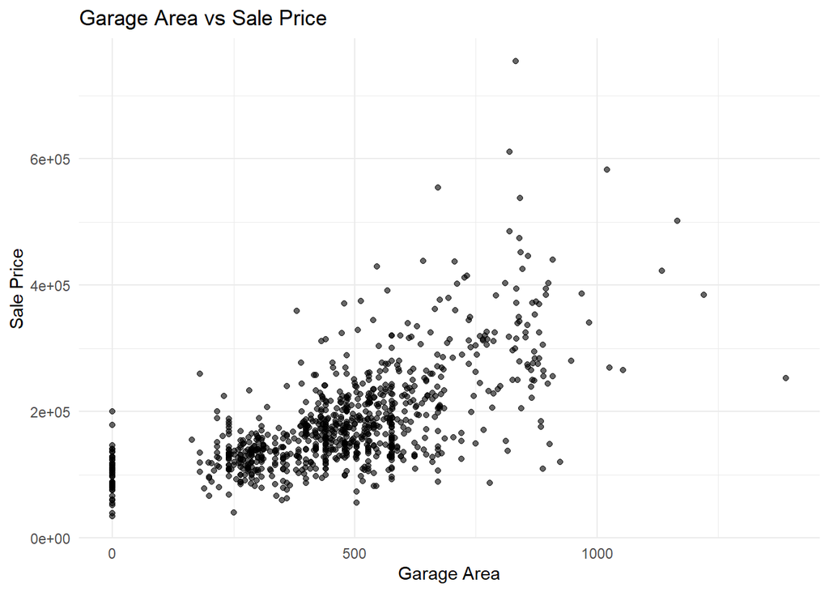

```r
ggplot(
  train_reg,
  aes(x = GarageArea, y = SalePrice)
) +
  geom_point(alpha = 0.6) +
  labs(
    title = "Garage Area vs Sale Price",
    x = "Garage Area",
    y = "Sale Price"
  ) +
  theme_minimal()
```

### Finished Basement Area and Sale Price

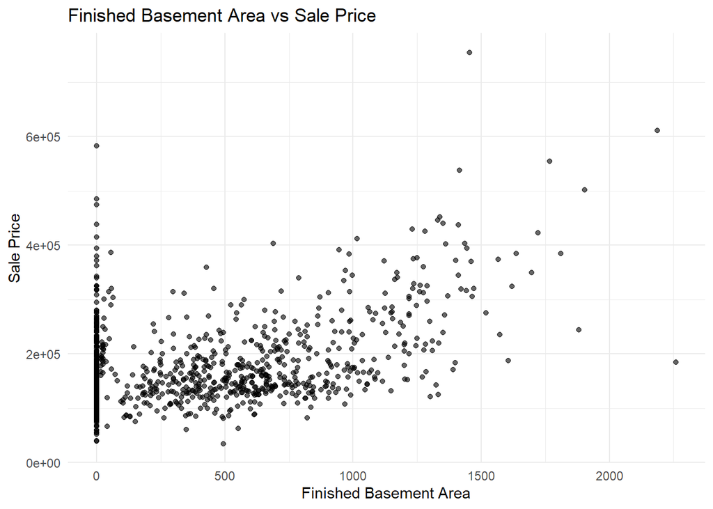

```r
ggplot(
  train_reg,
  aes(x = BsmtFinSF1, y = SalePrice)
) +
  geom_point(alpha = 0.6) +
  labs(
    title = "Finished Basement Area vs Sale Price",
    x = "Finished Basement Area",
    y = "Sale Price"
  ) +
  theme_minimal()
```

### Overall Quality Distribution

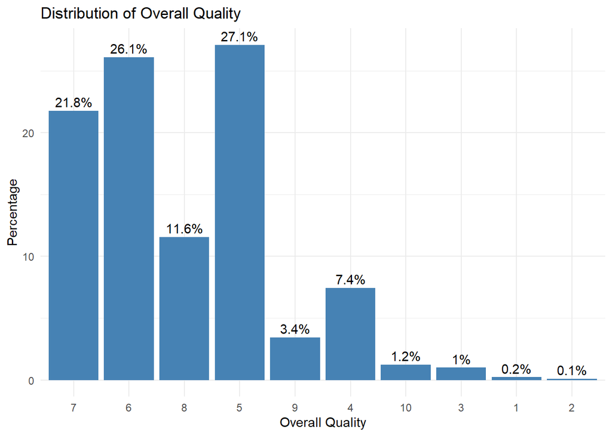

```r
quality_counts <- as.data.frame(
  table(train_reg$OverallQual)
)

names(quality_counts) <- c(
  "OverallQuality",
  "Count"
)

quality_counts$Percentage <-
  100 * quality_counts$Count /
  sum(quality_counts$Count)

ggplot(
  quality_counts,
  aes(
    x = OverallQuality,
    y = Percentage
  )
) +
  geom_col(fill = "steelblue") +
  geom_text(
    aes(
      label = paste0(
        round(Percentage, 1),
        "%"
      )
    ),
    vjust = -0.4
  ) +
  labs(
    title = "Distribution of Overall Quality",
    x = "Overall Quality",
    y = "Percentage"
  ) +
  theme_minimal()
```

## Regression Modeling

Two approaches are evaluated for house-price prediction:

- Multiple Linear Regression
- Random Forest Regression

### Evaluation Function

```r
regression_metrics <- function(actual, predicted) {

  mse <- mean(
    (actual - predicted)^2
  )

  rmse <- sqrt(mse)

  r_squared <- cor(
    actual,
    predicted
  )^2

  data.frame(
    MSE = mse,
    RMSE = rmse,
    R_Squared = r_squared
  )
}
```

## Multiple Linear Regression

```r
lm_model <- lm(
  SalePrice ~ .,
  data = train_reg
)

lm_predictions <- predict(
  lm_model,
  newdata = test_reg
)

lm_results <- regression_metrics(
  test_reg$SalePrice,
  lm_predictions
)

lm_results
```

```
##         MSE     RMSE R_Squared
## 1 562829945 23724.04 0.8526046
```

## Random Forest Regression

```r
set.seed(345)

rf_model <- randomForest(
  SalePrice ~ .,
  data = train_reg,
  ntree = 500,
  importance = TRUE
)

rf_predictions <- predict(
  rf_model,
  newdata = test_reg
)

rf_results <- regression_metrics(
  test_reg$SalePrice,
  rf_predictions
)

rf_results
```

```
##         MSE    RMSE R_Squared
## 1 686833058 26207.5 0.8243026
```

## Tuned Random Forest

A small tuning process is performed over different values of `mtry`.

```r
set.seed(345)

candidate_mtry <- c(
  2,
  4,
  6,
  8
)

candidate_mtry <- candidate_mtry[
  candidate_mtry <
    ncol(train_reg)
]

oob_errors <- numeric(
  length(candidate_mtry)
)

rf_models <- vector(
  "list",
  length(candidate_mtry)
)

for (i in seq_along(candidate_mtry)) {

  rf_models[[i]] <- randomForest(
    SalePrice ~ .,
    data = train_reg,
    ntree = 500,
    mtry = candidate_mtry[i],
    importance = TRUE
  )

  oob_errors[i] <-
    tail(
      rf_models[[i]]$mse,
      1
    )
}

best_index <- which.min(
  oob_errors
)

best_mtry <- candidate_mtry[
  best_index
]

cat(
  "Best mtry:",
  best_mtry,
  "\n"
)
```

```
## Best mtry: 6
```

```r
rf_tuned_model <-
  rf_models[[best_index]]

rf_tuned_predictions <- predict(
  rf_tuned_model,
  newdata = test_reg
)

rf_tuned_results <- regression_metrics(
  test_reg$SalePrice,
  rf_tuned_predictions
)

rf_tuned_results
```

```
##         MSE     RMSE R_Squared
## 1 661131534 25712.48 0.8314001
```

## Regression Model Comparison

```r
regression_comparison <- rbind(

  data.frame(
    Model = "Multiple Linear Regression",
    lm_results
  ),

  data.frame(
    Model = "Random Forest",
    rf_results
  ),

  data.frame(
    Model = "Tuned Random Forest",
    rf_tuned_results
  )
)

regression_comparison
```

```
##                        Model       MSE     RMSE R_Squared
## 1 Multiple Linear Regression 562829945 23724.04 0.8526046
## 2              Random Forest 686833058 26207.50 0.8243026
## 3        Tuned Random Forest 661131534 25712.48 0.8314001
```

## Random Forest Feature Importance

```r
rf_importance <- importance(
  rf_tuned_model
)

rf_importance_df <- data.frame(
  Feature = rownames(rf_importance),
  Importance = rf_importance[, 1]
)

rf_importance_df <- rf_importance_df[
  order(
    rf_importance_df$Importance,
    decreasing = TRUE
  ),
]

head(
  rf_importance_df,
  10
)
```

```
##                   Feature Importance
## OverallQual   OverallQual  62.203808
## GarageArea     GarageArea  25.608712
## FullBath         FullBath  19.484733
## HalfBath         HalfBath  16.603157
## BsmtFinSF1     BsmtFinSF1  15.885476
## Fireplaces     Fireplaces  15.825055
## LotArea           LotArea  15.282048
## YearRemodAdd YearRemodAdd   7.757220
## TotRmsAbvGrd TotRmsAbvGrd   4.740947
## BedroomAbvGr BedroomAbvGr   3.209520
```

# House Quality Classification

The second modeling problem classifies houses according to overall quality.

Properties with an overall quality score of **7 or higher** are assigned to the positive class.

```r
train_cls <- prepare_data(train_raw)
test_cls <- prepare_data(test_raw)

train_cls$OverallQual <- ifelse(
  train_raw$OverallQual >= 7,
  1,
  0
)

test_cls$OverallQual <- ifelse(
  test_raw$OverallQual >= 7,
  1,
  0
)
```

## Prepare Categorical Predictors

```r
classification_factor_cols <- c(
  "YrSold",
  "FullBath",
  "HalfBath",
  "BedroomAbvGr",
  "TotRmsAbvGrd",
  "Fireplaces",
  "YearRemodAdd"
)

for (col in classification_factor_cols) {

  all_levels <- unique(
    c(
      as.character(train_cls[[col]]),
      as.character(test_cls[[col]])
    )
  )

  train_cls[[col]] <- factor(
    train_cls[[col]],
    levels = all_levels
  )

  test_cls[[col]] <- factor(
    test_cls[[col]],
    levels = all_levels
  )
}
```

## Class Distribution

```r
class_distribution <- as.data.frame(
  table(train_cls$OverallQual)
)

names(class_distribution) <- c(
  "Class",
  "Count"
)

class_distribution$Percentage <-
  100 *
  class_distribution$Count /
  sum(class_distribution$Count)

class_distribution
```

```
##   Class Count Percentage
## 1     0   558         62
## 2     1   342         38
```

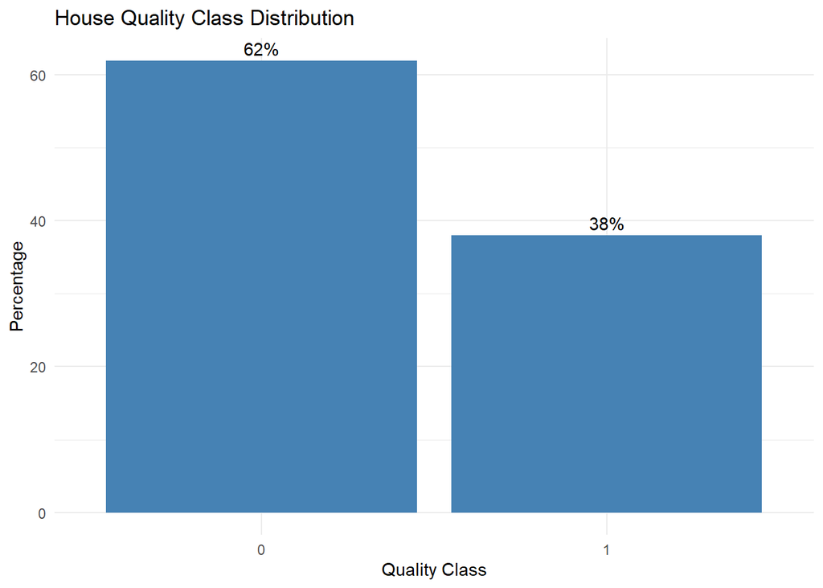

```r
ggplot(
  class_distribution,
  aes(
    x = Class,
    y = Percentage
  )
) +
  geom_col(fill = "steelblue") +
  geom_text(
    aes(
      label = paste0(
        round(Percentage, 1),
        "%"
      )
    ),
    vjust = -0.4
  ) +
  labs(
    title = "House Quality Class Distribution",
    x = "Quality Class",
    y = "Percentage"
  ) +
  theme_minimal()
```

## XGBoost Helper Functions

This version uses the native XGBoost interface instead of the older `caret::train(method = "xgbTree")` interface.

```r
make_xgb_matrices <- function(
  training_data,
  testing_data
) {

  train_x <- training_data[
    ,
    names(training_data) != "OverallQual"
  ]

  test_x <- testing_data[
    ,
    names(testing_data) != "OverallQual"
  ]

  combined <- rbind(
    train_x,
    test_x
  )

  combined_matrix <- model.matrix(
    ~ . - 1,
    data = combined
  )

  n_train <- nrow(
    train_x
  )

  x_train <- combined_matrix[
    1:n_train,
    ,
    drop = FALSE
  ]

  x_test <- combined_matrix[
    (n_train + 1):
      nrow(combined_matrix),
    ,
    drop = FALSE
  ]

  list(
    train = x_train,
    test = x_test
  )
}
```

### Classification Evaluation

```r
classification_metrics <- function(
  actual,
  predicted
) {

  actual <- as.integer(
    actual
  )

  predicted <- as.integer(
    predicted
  )

  TP <- sum(
    predicted == 1 &
    actual == 1
  )

  TN <- sum(
    predicted == 0 &
    actual == 0
  )

  FP <- sum(
    predicted == 1 &
    actual == 0
  )

  FN <- sum(
    predicted == 0 &
    actual == 1
  )

  accuracy <-
    (TP + TN) /
    (TP + TN + FP + FN)

  sensitivity <- ifelse(
    TP + FN == 0,
    NA,
    TP / (TP + FN)
  )

  specificity <- ifelse(
    TN + FP == 0,
    NA,
    TN / (TN + FP)
  )

  precision <- ifelse(
    TP + FP == 0,
    NA,
    TP / (TP + FP)
  )

  f1 <- ifelse(
    is.na(precision) |
      is.na(sensitivity) |
      precision + sensitivity == 0,
    NA,
    2 *
      precision *
      sensitivity /
      (precision + sensitivity)
  )

  data.frame(
    Accuracy = accuracy,
    Sensitivity = sensitivity,
    Specificity = specificity,
    Precision = precision,
    F1 = f1
  )
}
```

## XGBoost Training Function

```r
fit_xgb_model <- function(
  training_data,
  testing_data,
  seed = 345
) {

  set.seed(seed)

  matrices <- make_xgb_matrices(
    training_data,
    testing_data
  )

  y_train <- as.numeric(
    training_data$OverallQual
  )

  dtrain <- xgb.DMatrix(
    data = matrices$train,
    label = y_train
  )

  dtest <- xgb.DMatrix(
    data = matrices$test
  )

  params <- list(
    objective = "binary:logistic",
    eval_metric = "logloss",
    max_depth = 6,
    eta = 0.1,
    gamma = 0,
    min_child_weight = 1,
    subsample = 1,
    colsample_bytree = 1
  )

  model <- xgb.train(
    params = params,
    data = dtrain,
    nrounds = 100,
    verbose = 0
  )

  probability <- predict(
    model,
    dtest
  )

  prediction <- ifelse(
    probability >= 0.5,
    1,
    0
  )

  list(
    model = model,
    prediction = prediction,
    probability = probability,
    feature_names = colnames(
      matrices$train
    )
  )
}
```

# XGBoost — No Sampling

```r
xgb_no_sampling <- fit_xgb_model(
  train_cls,
  test_cls
)

no_sampling_results <-
  classification_metrics(
    test_cls$OverallQual,
    xgb_no_sampling$prediction
  )

no_sampling_results
```

```
##    Accuracy Sensitivity Specificity Precision        F1
## 1 0.8555556   0.7142857   0.9454545 0.8928571 0.7936508
```

### Confusion Matrix — No Sampling

```r
table(
  Predicted =
    xgb_no_sampling$prediction,
  Actual =
    test_cls$OverallQual
)
```

```
##          Actual
## Predicted  0  1
##         0 52 10
##         1  3 25
```

# Oversampling

The minority class is oversampled to create a more balanced training dataset.

```r
oversample_binary <- function(
  df,
  target = "OverallQual",
  seed = 345
) {

  set.seed(seed)

  class0 <- df[
    df[[target]] == 0,
  ]

  class1 <- df[
    df[[target]] == 1,
  ]

  target_size <- max(
    nrow(class0),
    nrow(class1)
  )

  class0_over <- class0[
    sample(
      seq_len(nrow(class0)),
      target_size,
      replace = TRUE
    ),
  ]

  class1_over <- class1[
    sample(
      seq_len(nrow(class1)),
      target_size,
      replace = TRUE
    ),
  ]

  result <- rbind(
    class0_over,
    class1_over
  )

  result[
    sample(seq_len(nrow(result))),
  ]
}

train_over <- oversample_binary(
  train_cls
)

table(
  train_over$OverallQual
)
```

```
##
##   0   1
## 558 558
```

## XGBoost — Oversampling

```r
xgb_over <- fit_xgb_model(
  train_over,
  test_cls
)

over_sampling_results <-
  classification_metrics(
    test_cls$OverallQual,
    xgb_over$prediction
  )

over_sampling_results
```

```
##    Accuracy Sensitivity Specificity Precision        F1
## 1 0.8666667   0.8285714   0.8909091 0.8285714 0.8285714
```

### Confusion Matrix — Oversampling

```r
table(
  Predicted =
    xgb_over$prediction,
  Actual =
    test_cls$OverallQual
)
```

```
##          Actual
## Predicted  0  1
##         0 49  6
##         1  6 29
```

# Undersampling

The majority class is undersampled to create a balanced training dataset.

```r
undersample_binary <- function(
  df,
  target = "OverallQual",
  seed = 345
) {

  set.seed(seed)

  class0 <- df[
    df[[target]] == 0,
  ]

  class1 <- df[
    df[[target]] == 1,
  ]

  target_size <- min(
    nrow(class0),
    nrow(class1)
  )

  class0_under <- class0[
    sample(
      seq_len(nrow(class0)),
      target_size,
      replace = FALSE
    ),
  ]

  class1_under <- class1[
    sample(
      seq_len(nrow(class1)),
      target_size,
      replace = FALSE
    ),
  ]

  result <- rbind(
    class0_under,
    class1_under
  )

  result[
    sample(seq_len(nrow(result))),
  ]
}

train_under <- undersample_binary(
  train_cls
)

table(
  train_under$OverallQual
)
```

```
##
##   0   1
## 342 342
```

## XGBoost — Undersampling

```r
xgb_under <- fit_xgb_model(
  train_under,
  test_cls
)

under_sampling_results <-
  classification_metrics(
    test_cls$OverallQual,
    xgb_under$prediction
  )

under_sampling_results
```

```
##    Accuracy Sensitivity Specificity Precision        F1
## 1 0.8444444   0.8285714   0.8545455 0.7837838 0.8055556
```

### Confusion Matrix — Undersampling

```r
table(
  Predicted =
    xgb_under$prediction,
  Actual =
    test_cls$OverallQual
)
```

```
##          Actual
## Predicted  0  1
##         0 47  6
##         1  8 29
```

# Classification Model Comparison

```r
classification_comparison <- rbind(

  data.frame(
    Model = "XGBoost - No Sampling",
    no_sampling_results
  ),

  data.frame(
    Model = "XGBoost - Oversampling",
    over_sampling_results
  ),

  data.frame(
    Model = "XGBoost - Undersampling",
    under_sampling_results
  )
)

classification_comparison
```

```
##                     Model  Accuracy Sensitivity Specificity Precision        F1
## 1   XGBoost - No Sampling 0.8555556   0.7142857   0.9454545 0.8928571 0.7936508
## 2  XGBoost - Oversampling 0.8666667   0.8285714   0.8909091 0.8285714 0.8285714
## 3 XGBoost - Undersampling 0.8444444   0.8285714   0.8545455 0.7837838 0.8055556
```

# XGBoost Feature Importance

Feature importance is calculated from the undersampled XGBoost model.

```r
xgb_importance <- xgb.importance(
  feature_names =
    xgb_under$feature_names,
  model =
    xgb_under$model
)

head(
  xgb_importance,
  10
)
```

```
##                    Feature        Gain       Cover  Frequency
##                     <char>       <num>       <num>      <num>
##  1:              SalePrice 0.655522271 0.390525985 0.21906924
##  2:                LotArea 0.124204675 0.201437804 0.24063564
##  3:             GarageArea 0.088327826 0.162233220 0.21282633
##  4:             BsmtFinSF1 0.076485498 0.136324848 0.16799092
##  5:             YrSold2007 0.011647323 0.013657395 0.02043133
##  6: YearRemodAddafter 2000 0.010741559 0.024329829 0.02099886
##  7:        TotRmsAbvGrd0-5 0.006606318 0.020546860 0.01929625
##  8:              HalfBath0 0.005427534 0.005032595 0.01362089
##  9:            Fireplaces1 0.004187911 0.010184712 0.02099886
## 10:             YrSold2009 0.004129757 0.007935463 0.01759364
```

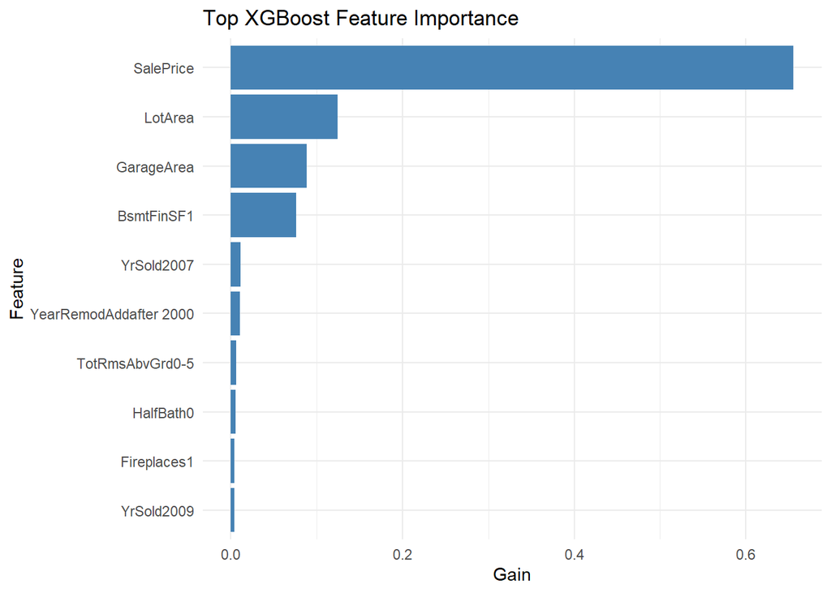

```r
top_importance <- head(
  xgb_importance,
  10
)

ggplot(
  top_importance,
  aes(
    x = reorder(
      Feature,
      Gain
    ),
    y = Gain
  )
) +
  geom_col(fill = "steelblue") +
  coord_flip() +
  labs(
    title =
      "Top XGBoost Feature Importance",
    x = "Feature",
    y = "Gain"
  ) +
  theme_minimal()
```

# Key Insights

The analysis demonstrates several important points:

- House prices depend on a combination of property characteristics rather than a single factor.
- Lot size, garage area, finished basement area, bathrooms, bedrooms, fireplaces, and overall quality can contribute to property value.
- Regression and ensemble approaches can be compared using MSE, RMSE, and R-squared.
- Class imbalance can materially affect classification performance.
- Oversampling and undersampling provide alternative approaches for improving minority-class prediction.
- Feature importance helps identify the variables contributing most strongly to model predictions.